# GWAS sharing EDA

Guillermo Reales

2022-06-14

# Background

We want to motivate researchers to share more GWAS summary statistics with the community, and we hypothesise that sharing can result in more citations.

This notebook contains part of the EDA within this project

# Prepare data

```r
## Load packages
library(data.table)
library(magrittr)
library(ggplot2)
library(iCiteR)
```

```r
## List of publications and available summary statistics downloaded on 2022-05-24
pubs <- fread("../data/gwas-catalog-v1.0.3-studies-r2022-05-17.tsv", sep="\t") # Published studies
ss <- fread("../data/list_gwas_summary_statistics_24_May_2022.csv")  # Studies with summary statistics
SCR <- fread("../data/scimagojr_2021.csv") # SCimagoJR dataset with journal impact factors for year 2021
NLM <- fread("../data/NLM_journals.tsv") # NLM catalog with journal names, ISSN, and abbreviations

## Replace key column names by something more useful
setnames(pubs, c("FIRST AUTHOR", "PUBMED ID", "STUDY ACCESSION", "ASSOCIATION COUNT"), c("First_Author", "PMID", "accession", "association_count"))
setnames(ss, c("PubMed ID", "Study accession"), c("PMID", "accession"))

## Label studies with summary statistics and check how many of them in each study
pubs[, Public_ss := ifelse(PMID %in% ss$PMID, "Y","N")]
ds_num <- ss[, .(ds_count = .N), by=PMID] # Number of published summary statistics datasets
pubs <- merge(pubs, ds_num, by="PMID", all.x=TRUE)
pubs[is.na(ds_count), ds_count:=0]

## Update changed PMID. This PMID was removed because it was duplicated in PubMed, so we update it to the current ID. It didn't have summary statistics.
pubs[PMID == 24513584, PMID:=24516880]

## Subset columns to keep key information per paper
m <- unique(pubs[, .(PMID, Public_ss, ds_count, DATE, First_Author)])

# Get citation info. Retrieving is capped at 1000 articles, so we'll run it 6 times
citinfo <- lapply(0:5, function(x){
    start_idx = (x * 1000) + 1
    if(x == 0) start_idx = 1
    end_idx = start_idx + 999
    if(end_idx > nrow(m)) end_idx = nrow(m)

    pmids <- m$PMID[start_idx:end_idx]
    message("Getting metrics for papers ", start_idx, " to ", end_idx)
    papers <- get_metrics(pmids)
})
citinfo <- rbindlist(citinfo)

# Extract key data for analysis and merge both datasets
m <- merge(m, citinfo, by.x="PMID", by.y="pmid")

# Match Journal Abbreviations from GWAS catalog with journal names

jab <- unique(m$journal) # unique abbreviations
NLM.g <- NLM[ MedAbbr %in% jab]
# There are some duplications, let's get rid of them
dup.nlmg <- NLM.g[duplicated(MedAbbr), MedAbbr]
NLM.g[MedAbbr %in% dup.nlmg]
NLM.g <- NLM.g[!NlmId %in% c("7803060", "0074126")] # Checked duplicated in SCR and the latter two didn't have an entry by ISSN in SCR, so we'll remove them

# Now we need to match SCR info with NLM.g. We'll do it by matching ISSN.
# SCR file has two types of ISSN (Online and Print) in one comma-separated string, and the order is not constant (????) so we'll try to separate and match
NLM.g[, Issn.print:=gsub("-", "", `ISSN (Print)`)][, Issn.online:=gsub("-", "", `ISSN (Online)`)] # SCR Issn are missing the hyphen, so let's remove it
mSCR <- copy(SCR)
mSCR[, c("V1", "V2", "V3", "V4"):=tstrsplit(Issn, ", ")]
guide.SCR <- melt(mSCR, id.vars = "Title", measure.vars =  c("V1", "V2", "V3", "V4"))
guide.SCR <- na.omit(guide.SCR)
guide.NLM <- melt(NLM.g, id.vars = "MedAbbr", measure.vars = c("Issn.print", "Issn.online"))
m.guides <- merge(guide.SCR, guide.NLM, by="value")
m.guides <- unique(m.guides[, .(Title, MedAbbr)])
setnames(m.guides, "Title", "SCR.title")

m <- merge(m, m.guides, by.x = "journal", by.y = "MedAbbr", all.x = TRUE) # Merge with guides to get the journal title
sSCR <- SCR[ Title %in% m$SCR.title, .(Title, SJR, `SJR Best Quartile`, `H index`, Publisher)][, SJR:=as.numeric(gsub(",", ".", SJR))] # Select columns to use. Also replace comma for numeric SJR
m <- merge(m, sSCR, by.x = "SCR.title", by.y="Title", all.x = TRUE)
setnames(m, c("H index", "SJR Best Quartile", "journal", "DATE", "year", "title", "authors"), c("H_index", "SJR_Best_Quartile","Journal", "Date", "Year", "Title", "Authors"))

# Order m
setcolorder(m, c("PMID", "Public_ss", "ds_count", "Year", "First_Author", "Title", "Authors", "Date", "citation_count","citations_per_year", "relative_citation_ratio", "expected_citations_per_year", "cited_by", "references", "doi", "Journal", "SJR", "H_index", "SJR_Best_Quartile", "Publisher"))

# We want to get the citation history of the articles, we'll extract this info in the same fashion as we did previously. We'll extract citing articles from the `cited_by` column and retrieve their year, then we'll be able to count number of citations each year.
cith <- m[,.(PMID, cited_by)]
cith[, paste0("V", 1:6770):= tstrsplit(cited_by, " ")] # Max citations is 6770, so we'll need that number of columns
cith <- melt(cith, id.vars = "PMID", measure.vars = paste0("V", 1:6770))
cith <- na.omit(cith)
cith[, variable:=NULL]
lup <- unique(cith$value) # Lookup items


citing.items <- lapply(0:188, function(x){
    start_idx = (x * 1000) + 1
    if(x == 0) start_idx = 1
    end_idx = start_idx + 999
    if(end_idx > length(lup)) end_idx = length(lup)

    pmids <- lup[start_idx:end_idx]
    message("Getting metrics for papers ", start_idx, " to ", end_idx)
    papers <- get_metrics(pmids)
})
citing.items <- rbindlist(citing.items)
citing.items <- citing.items[,.(pmid, year)]
citing.items$pmid <- as.character(citing.items$pmid)
cith <- merge(cith, citing.items, by.x = "value", by.y = "pmid")
# Now create a summary
sum.cith <- cith[, .(count = .N), by=c("PMID", "year")]

# Store data
fwrite(pubs, "../data/Publications_20220525.tsv", sep="\t")
fwrite(citinfo, "../data/Citation_info_20220525.tsv", sep="\t")
fwrite(m, "../data/Main_data_20220610.tsv", sep="\t", na = NA)
fwrite(sum.cith, "../data/Citations_per_year_20220611.tsv", sep="\t")
```

For the most subsequent analyses, we’ll consider full years only, so we’ll remove papers published in 2022 (they haven’t had enough time to accrue many citations anyway).

```r
m.full <- copy(m)
m <- m[Year < 2022]
```

# Data visualisation

We have several initial questions about the data.

Note that we’ll use citations per year as a response variable, but also relative citation ratio (RCR), as it is a article level and field independent metric that uses co-citation network to field- and time-normalise the number of citations a given article has received.

However, as we could expect, RCR is highly correlated with citation count and citations per year:

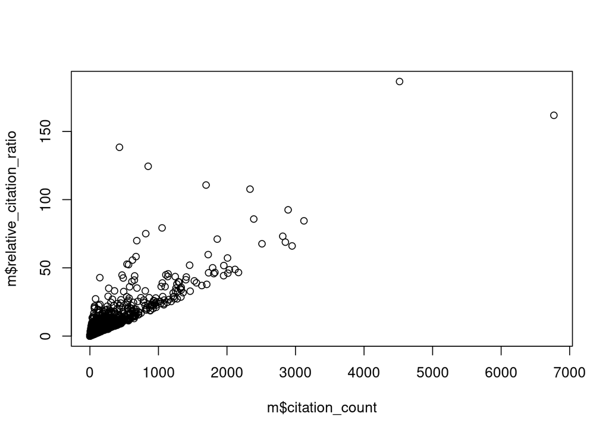

```r
plot(m$citation_count, m$relative_citation_ratio)
```

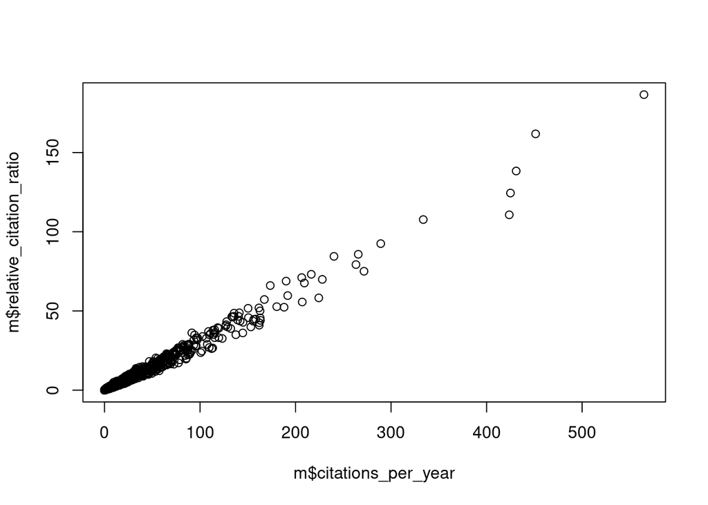

```r
plot(m$citations_per_year, m$relative_citation_ratio)
```

## 1 - What’s the proportion of studies with shared or not shared data in GWAS catalog?

```r
table(m.full$Public_ss) / nrow(m.full)
```

```
##
##        N        Y
## 0.895066 0.104934
```

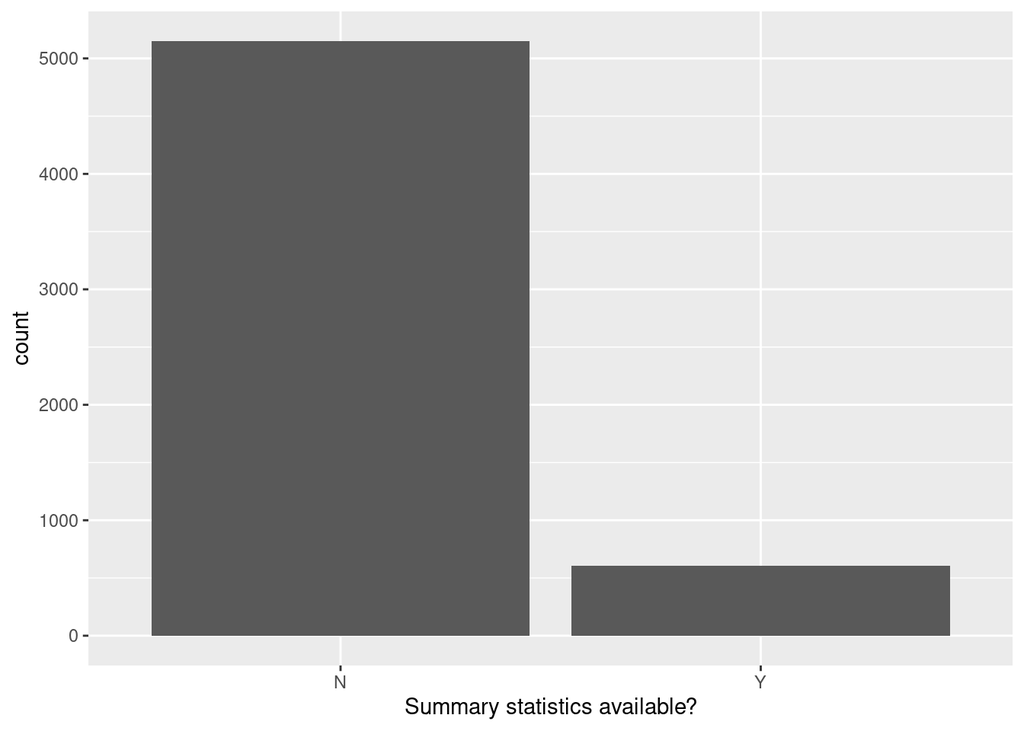

```r
ggplot(m.full, aes(x=Public_ss))+ geom_bar(stat="count") + xlab("Summary statistics available?")
```

Most studies don’t have shared summary statistics in GWAS catalog. Approximately 1/10 studies share summary statistics.

## 2 - How did sharing change over time?

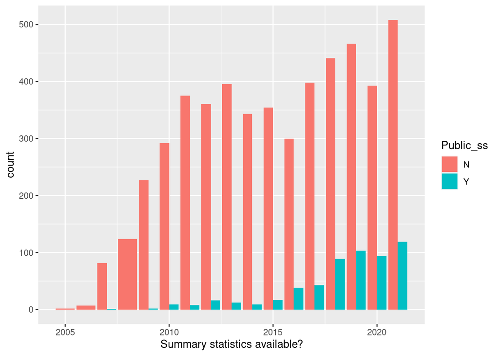

```r
ggplot(m, aes(x=Year, fill=Public_ss))+ geom_bar(position = "dodge", stat="count") + xlab("Summary statistics available?")
```

Or as a proportion:

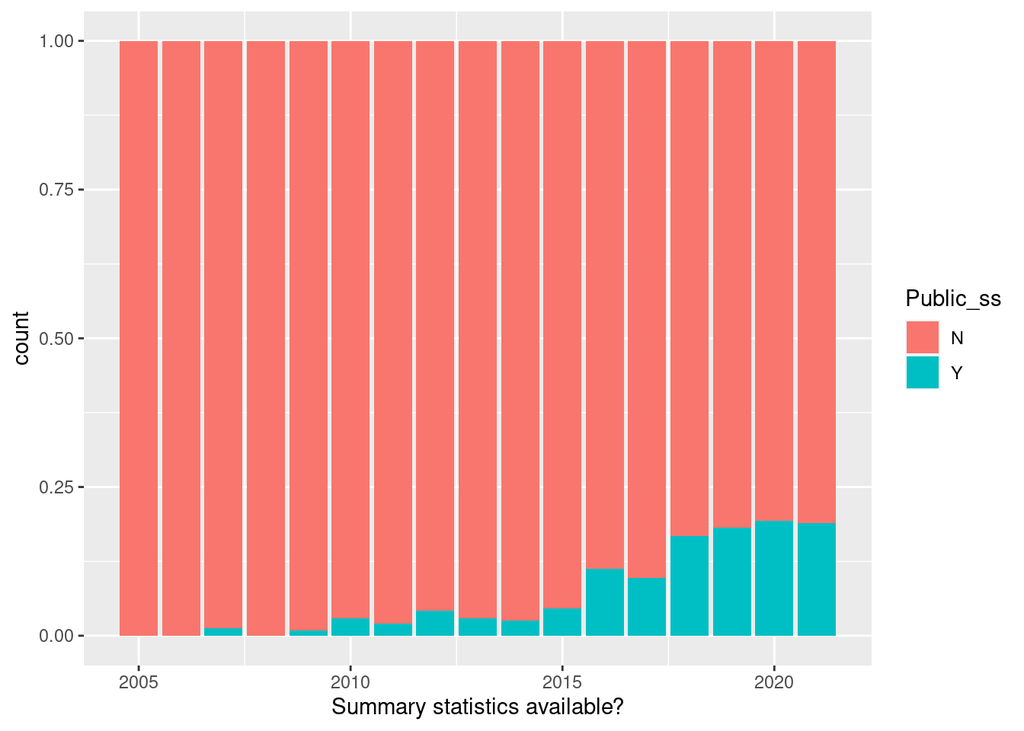

```r
ggplot(m, aes(x=Year, fill=Public_ss))+ geom_bar(position = "fill", stat="count") + xlab("Summary statistics available?")
```

It looks like sharing is gaining momentum, but still represent the minority of all reported studies.

## 3 - Do sharing result in higher citations overall?

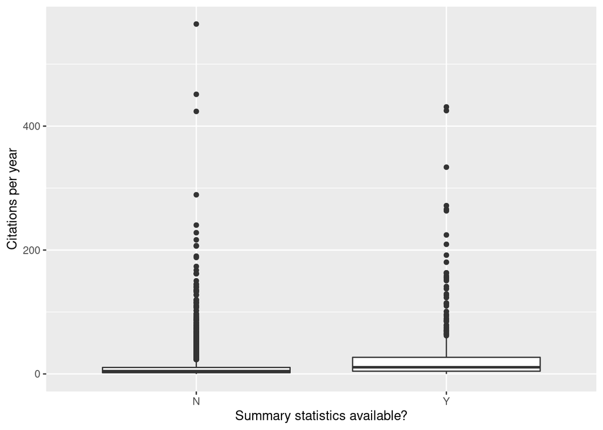

```r
ggplot(m, aes(x = Public_ss, y=citations_per_year)) + geom_boxplot() + xlab("Summary statistics available?") + ylab("Citations per year")
```

## 4 - How have citation patterns changed over time?

It is no secret that GWAS used to be a bigger deal in the past that they are today. Have GWAS papers become less influential?

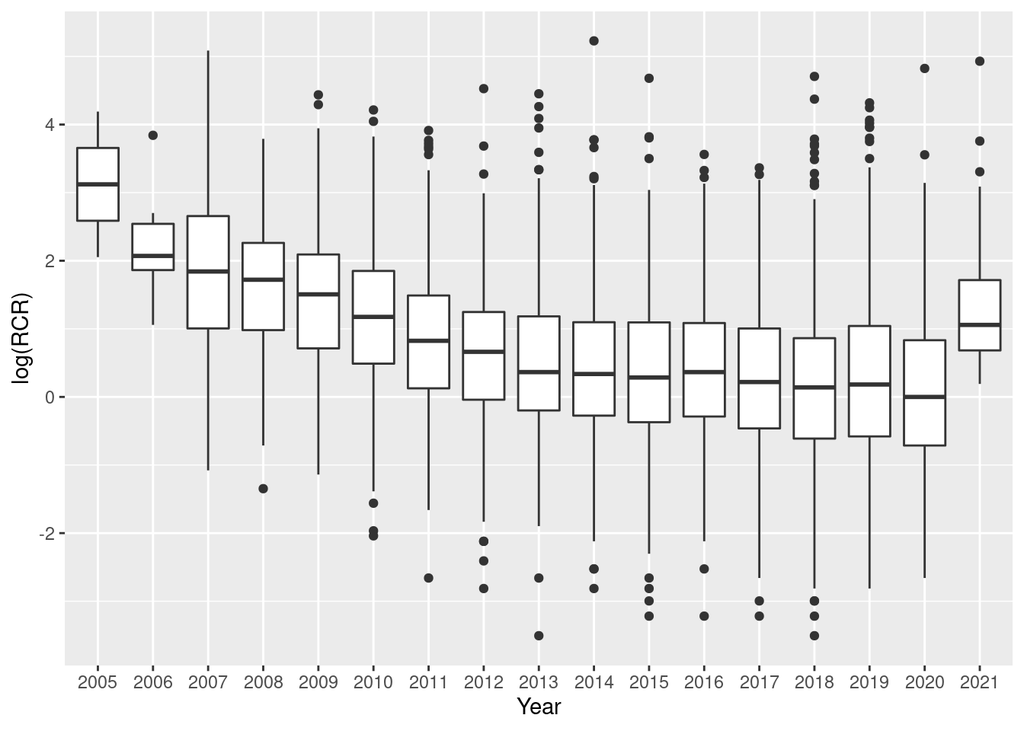

```r
ggplot(m, aes(x=as.factor(Year), y=log(relative_citation_ratio)))+ geom_boxplot() + xlab("Year") + ylab("log(RCR)")
```

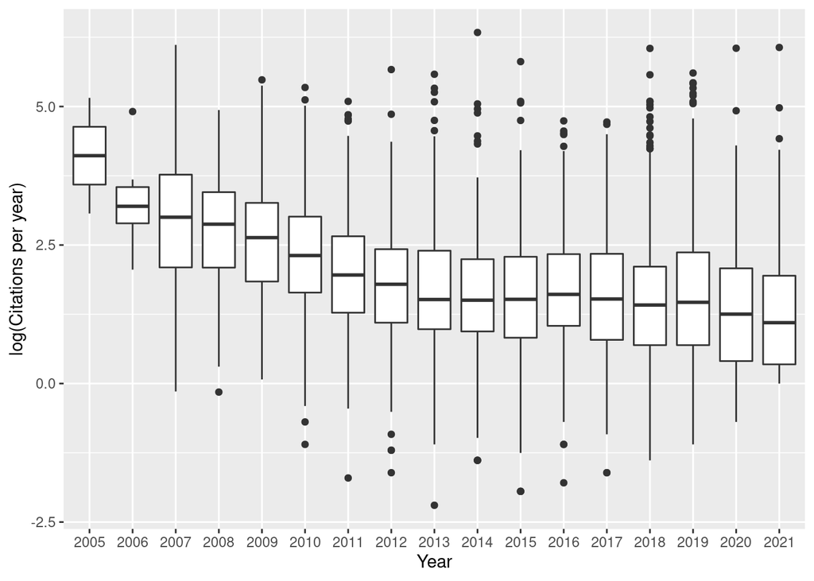

```r
ggplot(m, aes(x=as.factor(Year), y=log(citations_per_year)))+ geom_boxplot() + xlab("Year") + ylab("log(Citations per year)")
```

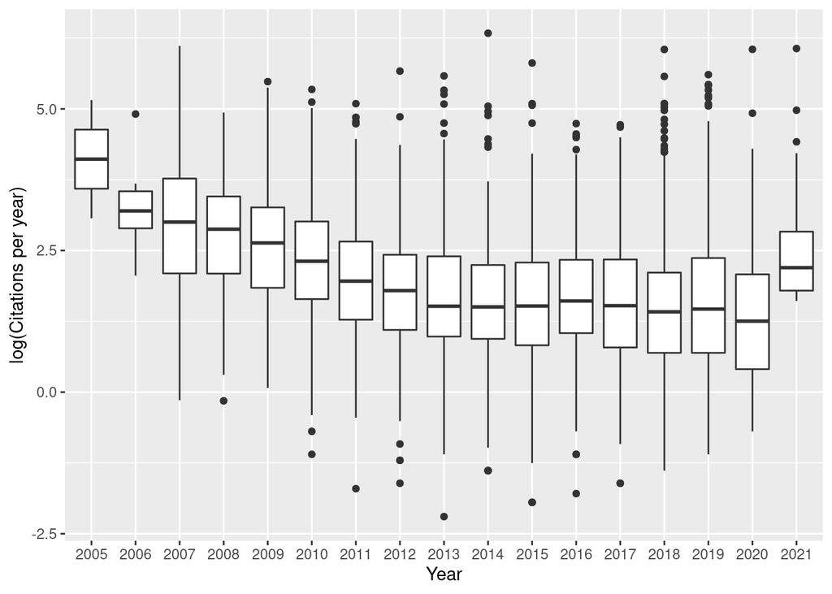

```r
ggplot(m[!is.na(relative_citation_ratio)], aes(x=as.factor(Year), y=log(citations_per_year)))+ geom_boxplot() + xlab("Year") + ylab("log(Citations per year)")
```

We’ve plotted RCR and CPY in the log scale, to make it easier to see the trend. In general, GWAS impact seems to peak in their early years (until ~2010) and then plateaued with a slightly decreasing trend. However, we see a peak in RCR and CPY in 2021. Note that many recent articles with few citations don’t have a RCR. If we consider these papers, the trend is lost for CPY, since many papers without RCR do have few (or no) citations. However, if we consider papers with RCR data only, we also see the trend in CPY.

But what happened in 2021?

```r
m[Year == 2021 & !is.na(relative_citation_ratio), .(PMID, Public_ss, Title, relative_citation_ratio, citations_per_year)][order(relative_citation_ratio, decreasing = T)][1:15]
```

```
##         PMID Public_ss
##  1: 33307546         Y
##  2: 34237774         N
##  3: 34002096         N
##  4: 33462485         Y
##  5: 33462484         Y
##  6: 33398198         N
##  7: 33888907         N
##  8: 33589840         Y
##  9: 33495597         N
## 10: 33495596         N
## 11: 33536081         N
## 12: 33627673         Y
## 13: 34017140         Y
## 14: 33589841         Y
```

[output cut: 33 more lines]

Of course, COVID! But not only that, we also have large studies on bipolar disorder, gut microbiome composition, blood biomarkers, prostate cancer, etc.

Note that among the first 15, the proportion of shared and non-shared is more or less balanced.

We’ll now explore the differences between sharing and non-sharing studies

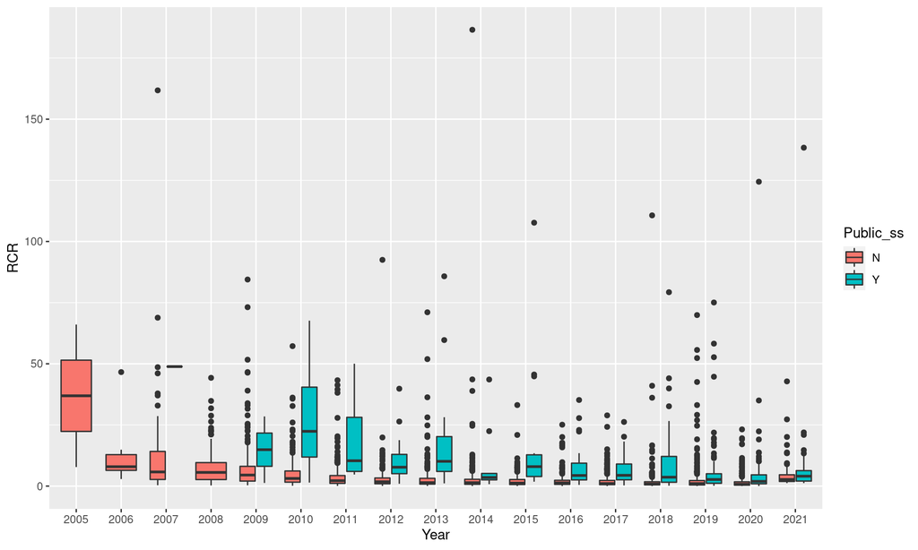

```r
ggplot(m, aes(x=as.factor(Year), y=relative_citation_ratio, fill=Public_ss))+ geom_boxplot() + xlab("Year") + ylab("RCR")
```

Let’s try log scale

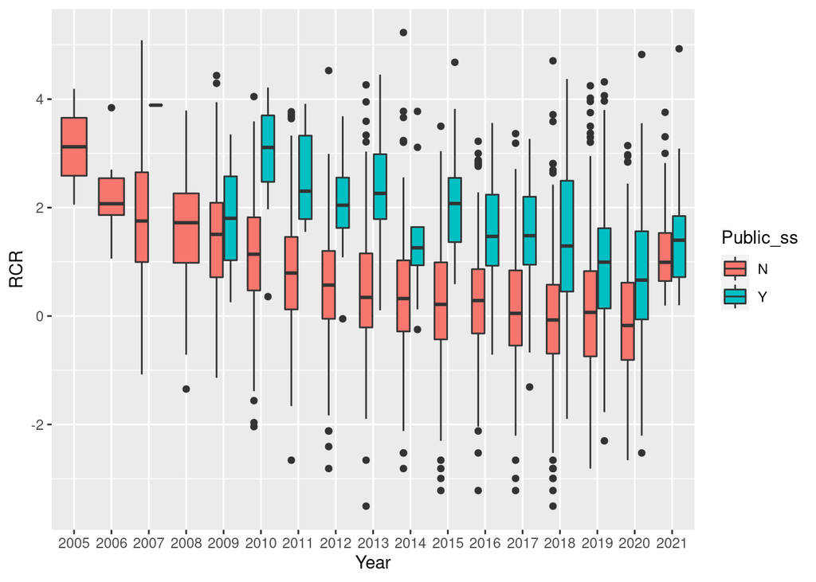

```r
ggplot(m, aes(x=as.factor(Year), y=log(relative_citation_ratio), fill=Public_ss))+ geom_boxplot() + xlab("Year") + ylab("RCR")
```

We can see two things:

1. RCR for GWAS papers seem to be declining/flattening over time (consistent with GWAS coming of age and not being a novel thing anymore).
2. There seems to be a consistent positive effect of sharing over the years.

## 5 - Are there differences between journals?

We know that some journals are more cited than others and some publish more GWAS than others. Let’s take a look at the journal profile

```r
m[, .N, by=Journal][order(-N)]
```

```
##                Journal   N
##   1:         Nat Genet 624
##   2:     Hum Mol Genet 289
##   3:        Nat Commun 275
##   4:          PLoS One 270
##   5:        PLoS Genet 230
##  ---
## 708:          Vox Sang   1
## 709:      Yonsei Med J   1
## 710:           mSphere   1
## 711:          mSystems   1
## 712: NPJ Breast Cancer   1
```

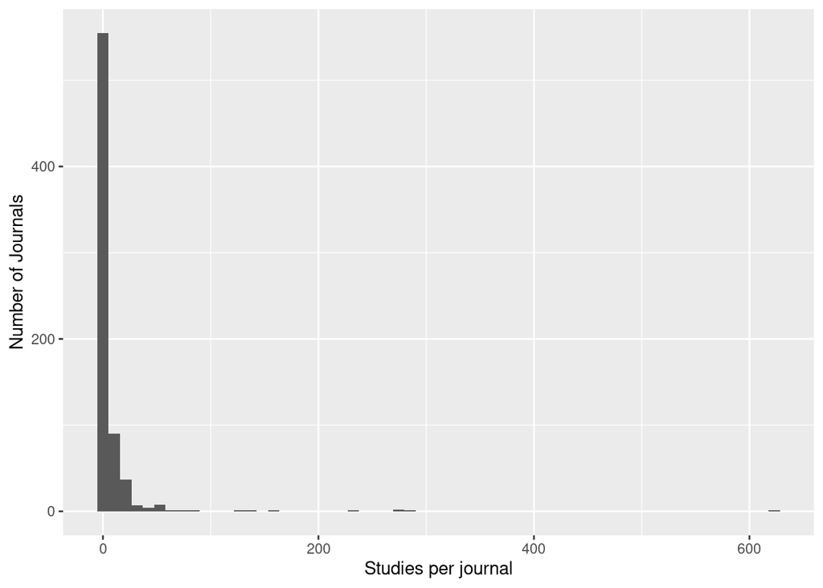

```r
ggplot(m[, .N, by=Journal], aes(x=N)) + geom_histogram(bins = 60) + xlab("Studies per journal") + ylab("Number of Journals")
```

*Nature Genetics* is by far the journal with most GWAS in GWAS catalog.

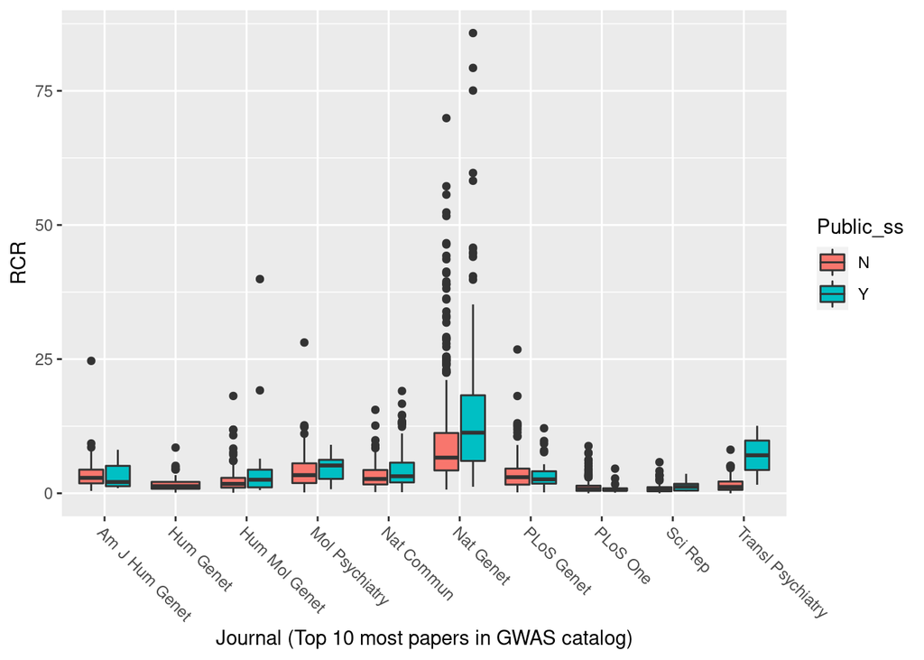

```r
top10 <- m[, .N, by=Journal][order(-N)][1:10, Journal]
mj <- m[Journal %in% top10 ]
ggplot(mj, aes(x=Journal, y=relative_citation_ratio, fill=Public_ss))+ geom_boxplot() + xlab("Journal (Top 10 most papers in GWAS catalog)") + ylab("RCR") + theme(axis.text.x = element_text(angle = -45, hjust=0))
```

# 6 - What about Impact Factor?

We’d assume that IF will result with more citations, but is it associated with more sharing? I downloaded 2021 data from Scimago Journal and Country Rank (https://www.scimagojr.com/) to get some bibliometrics on the journals. **Note:** 27 Journals didn’t have SJR, either because they’re too new or because they’ve been discontinued

```r
unique(m[, .(SJR, Journal)]) %>% .[is.na(SJR)]
```

```
##     SJR                            Journal
##  1:  NA                        Age (Dordr)
##  2:  NA                     Ann Transl Med
##  3:  NA                Arch Gen Psychiatry
##  4:  NA                    Arch Intern Med
##  5:  NA                        Arch Neurol
##  6:  NA                    Arthritis Rheum
##  7:  NA          BMC Complement Altern Med
##  8:  NA      Biol Psychiatry Glob Open Sci
##  9:  NA                       Brain Commun
## 10:  NA                         Cell Genom
## 11:  NA              Circ Cardiovasc Genet
## 12:  NA                       Exp Ther Med
## 13:  NA                         Explor Med
## 14:  NA                           J Androl
## 15:  NA                         J BioX Res
## 16:  NA              J Nutr Intermed Metab
## 17:  NA         J Nutrigenet Nutrigenomics
## 18:  NA                   Kidney Int Suppl
## 19:  NA Mayo Clin Proc Innov Qual Outcomes
## 20:  NA                     Mol Endocrinol
## 21:  NA                Mol Neuropsychiatry
## 22:  NA                NAR Genom Bioinform
## 23:  NA                   NPJ Precis Oncol
## 24:  NA                          Nat Aging
## 25:  NA                 Papillomavirus Res
## 26:  NA                   World J Diabetes
## 27:  NA                     BMC Genom Data
##     SJR                            Journal
```

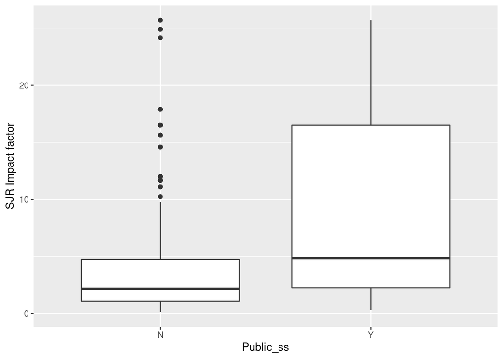

```r
ggplot(m, aes(x = Public_ss, y = SJR)) + geom_boxplot()+ ylab("SJR Impact factor")
```

Papers published in higher impact factor journals tend to share more. This might be due to higher pressure and commitment from larger journals with open science?

Another potential explanation for this could be that large consortia working on large projects may get to publish on higher IF journals and get more citations, but they get the pressure to share from their funders rather than the journals themselves.

Let’s take a closer look at the top journals by IF

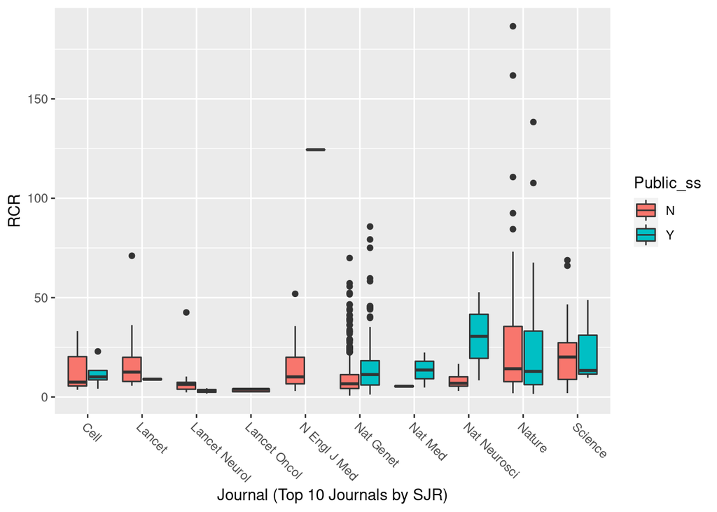

```r
topj <- m[ , .(Journal, SJR)] %>% unique %>% .[order(SJR, decreasing = TRUE)] %>% .[1:10, Journal]
mtop <- m[Journal %in% topj]
ggplot(mtop, aes(x=Journal, y=relative_citation_ratio, fill=Public_ss))+ geom_boxplot() + xlab("Journal (Top 10 Journals by SJR)") + ylab("RCR") + theme(axis.text.x = element_text(angle = -45, hjust=0))
```

So there are some notable differences among top journals, from having almost no shared datasets (NEJM), to mostly share (Nat Med). For Cell, Nature and Science, sharing or not doesn’t seem to make a great difference, although for Nature Genetics, Nat Med and Nature Neuroscience it seems that papers with shared data gets more citations.

This may mean that top journals do not necessarily enforce data sharing policies (at least, not of GWAS sumstats to GWAS catalog), or haven’t always done so. However, when published in the same top journals, sharers seem to get more citations.

Has this changed over time?

Let’s take a look at the patterns of the top journals in the first and last half of the 2010s (since few papers shared data before 2009).

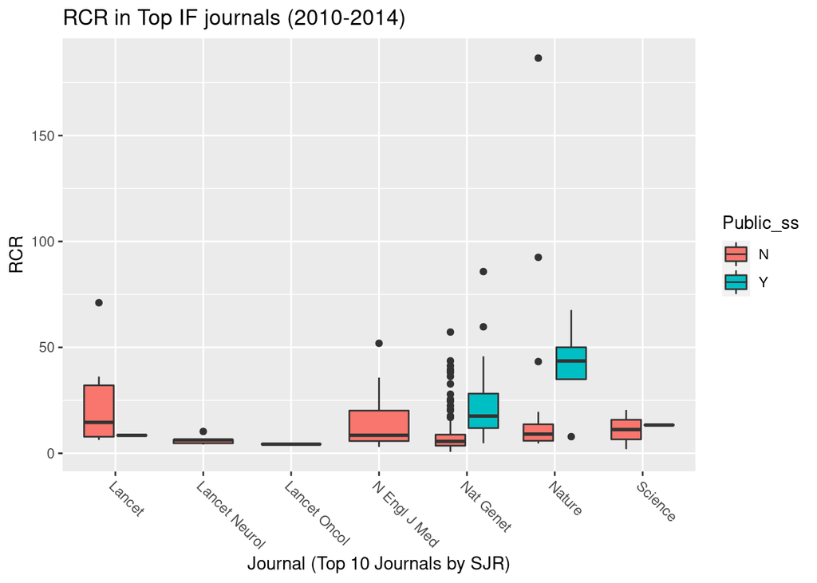

```r
ggplot(mtop[Year >= 2010 & Year <= 2014 ], aes(x=Journal, y=relative_citation_ratio, fill=Public_ss))+ geom_boxplot() + xlab("Journal (Top 10 Journals by SJR)") + ylab("RCR") + theme(axis.text.x = element_text(angle = -45, hjust=0)) + ggtitle("RCR in Top IF journals (2010-2014)")
```

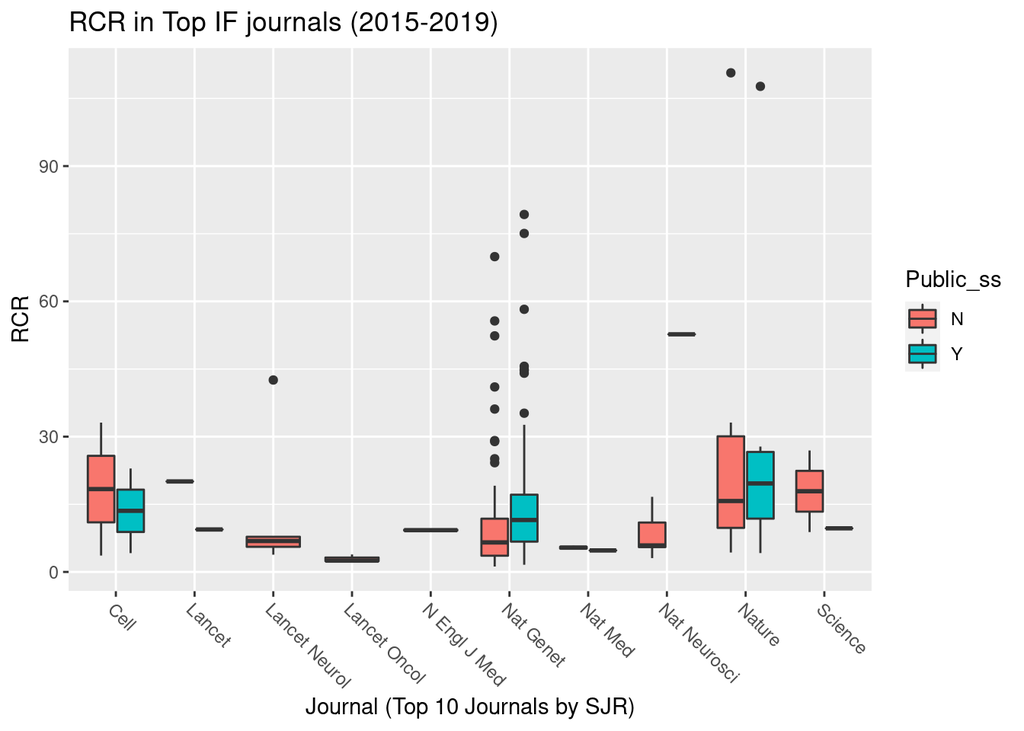

```r
ggplot(mtop[Year >= 2015 & Year <= 2019 ], aes(x=Journal, y=relative_citation_ratio, fill=Public_ss))+ geom_boxplot() + xlab("Journal (Top 10 Journals by SJR)") + ylab("RCR") + theme(axis.text.x = element_text(angle = -45, hjust=0)) + ggtitle("RCR in Top IF journals (2015-2019)")
```

```r
table(mtop[Year >= 2010 & Year <= 2014, Public_ss])
```

```
##
##   N   Y
## 303  32
```

```r
table(mtop[Year >= 2015 & Year <= 2019, Public_ss])
```

```
##
##   N   Y
## 115  81
```

So there seems to be a temporary effect in the 2010s. It looks like fewer papers were published in 2015-2019, more of them shared summary statistics but this wasn’t reflected in RCR as much as it did in 2010-2014. This could be explained by the general GWAS trend towards being less often published in top journals over time and getting fewer citations.

In any case, it looks like either top journals don’t exert that much pressure on authors sharing their data – or at least they share their data in a different platform and format!

Although Journal impact factor is not a good proxy to individual article quality, we’d expect to see a correlation between citations (RCR) and the Impact factor of the journals they were published, and overall this seems to be the case. But does it look different between sharers and non-sharers?

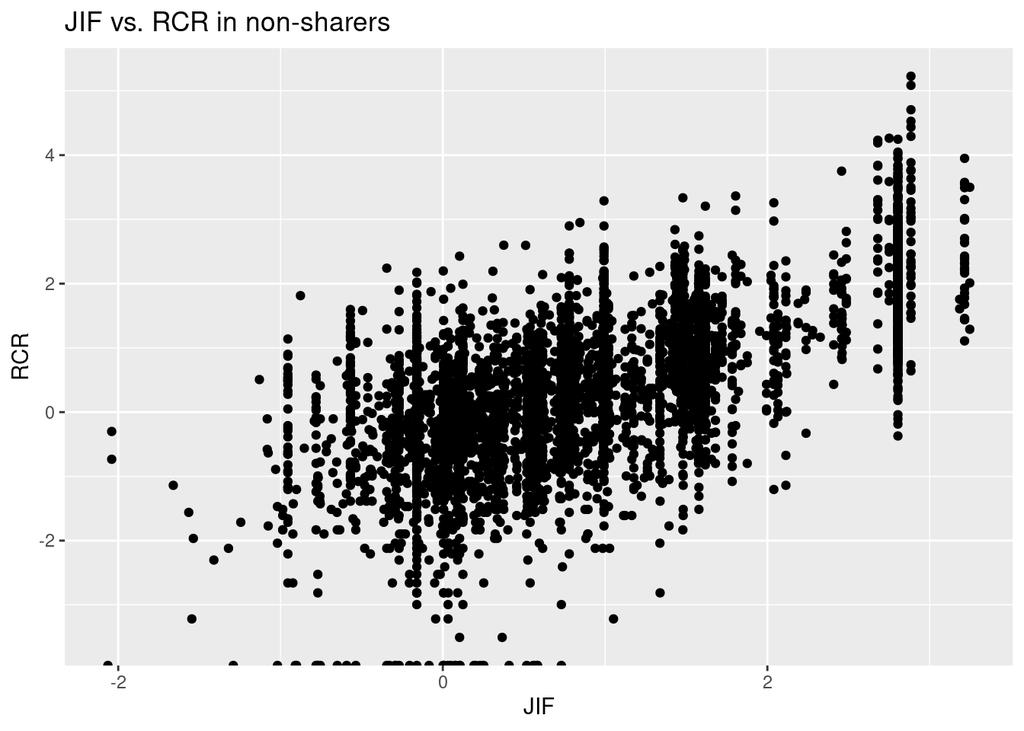

```r
ggplot(m[Public_ss == "N"], aes(x = log(SJR), y = log(relative_citation_ratio))) + geom_point() + xlab("JIF") + ylab("RCR") + ggtitle("JIF vs. RCR in non-sharers")
```

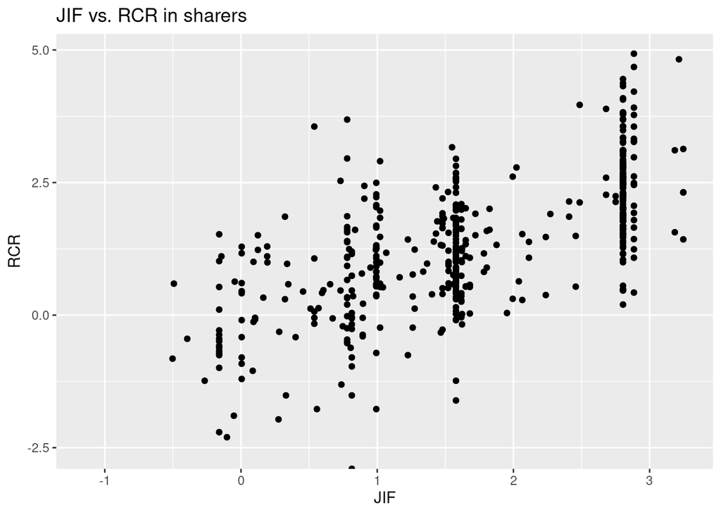

```r
ggplot(m[Public_ss == "Y"], aes(x = log(SJR), y = log(relative_citation_ratio))) + geom_point() + xlab("JIF") + ylab("RCR") + ggtitle("JIF vs. RCR in sharers")
```

Both groups seem to show the same correlation, but it looks like sharers tend to concentrate around higher impact factors?

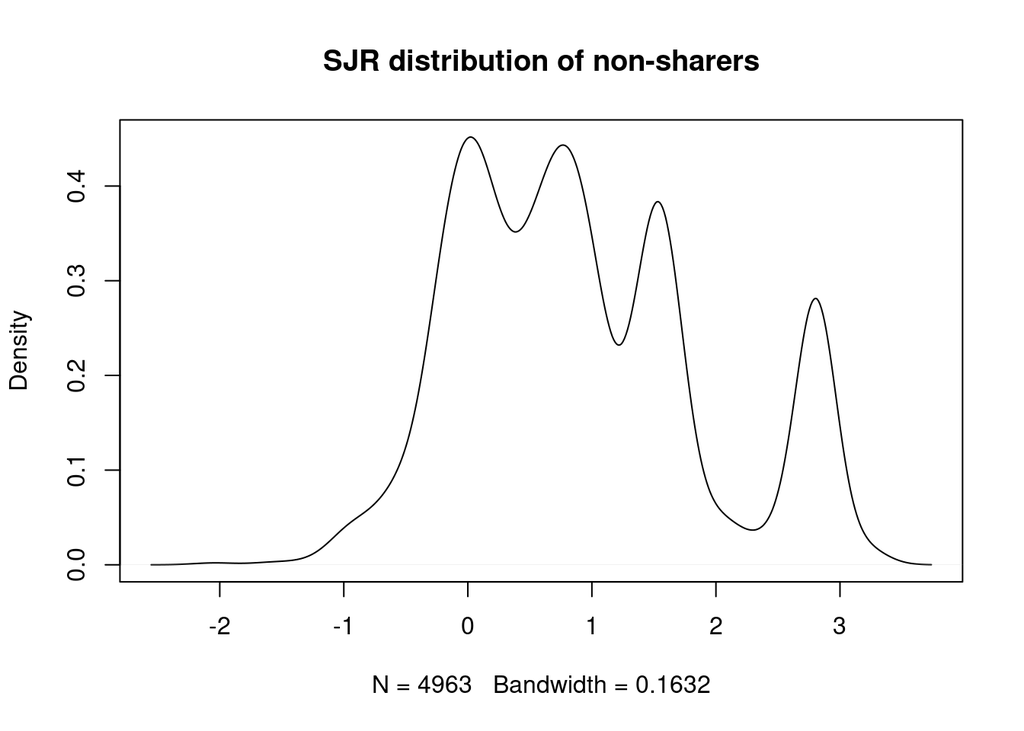

```r
plot(density(log(m[Public_ss == "N" & !is.na(SJR)]$SJR)), main = "SJR distribution of non-sharers")
```

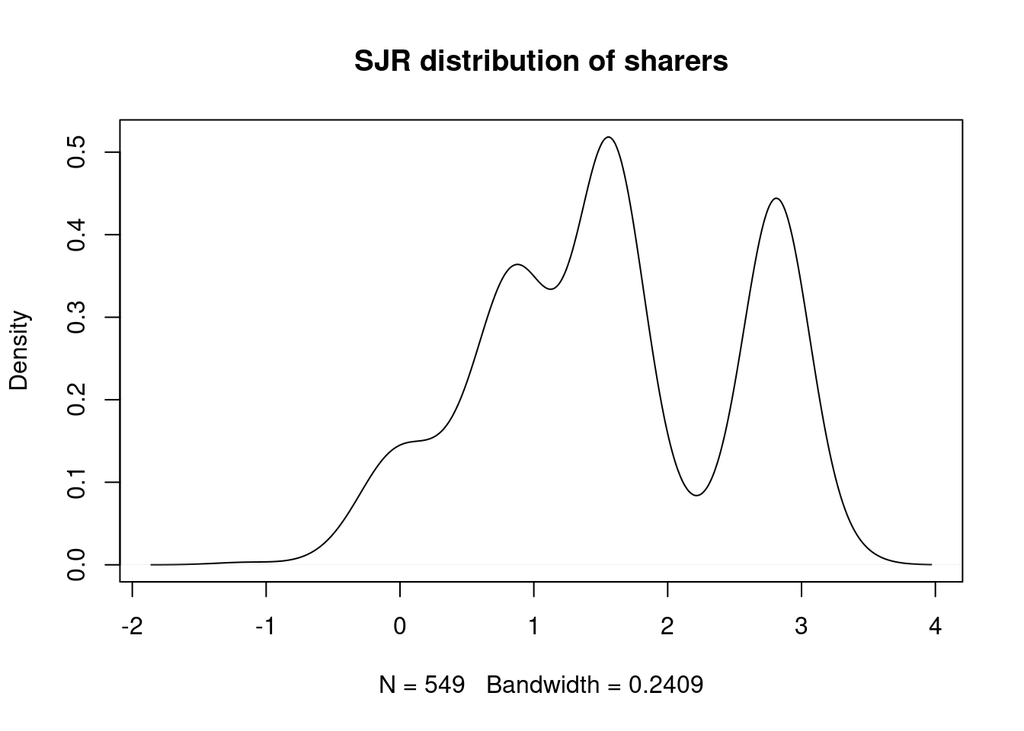

```r
plot(density(log(m[Public_ss == "Y" & !is.na(SJR)]$SJR)), main = "SJR distribution of sharers")
```

And what about RCR?

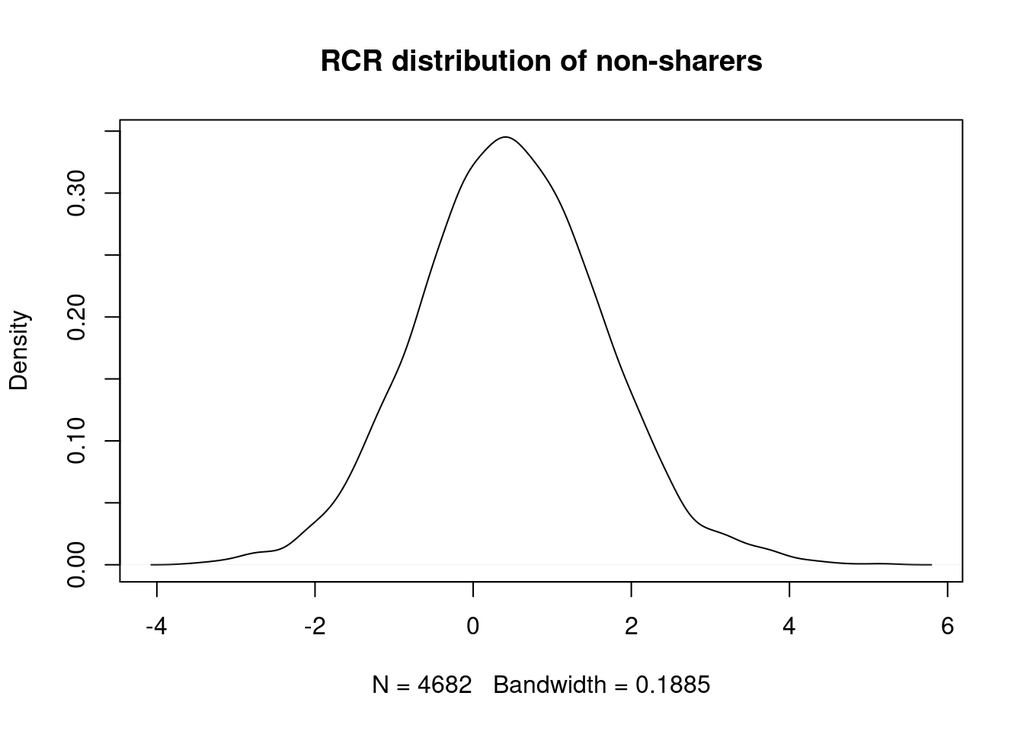

```r
plot(density(log(m[Public_ss == "N" & !is.na(relative_citation_ratio)]$relative_citation_ratio)), main = "RCR distribution of non-sharers")
```

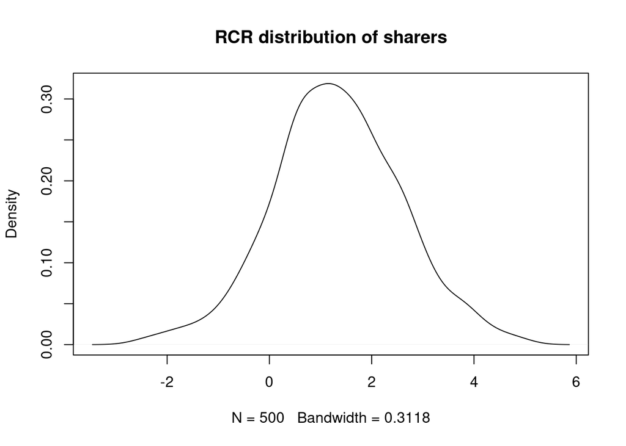

```r
plot(density(log(m[Public_ss == "Y" & !is.na(relative_citation_ratio)]$relative_citation_ratio)), main = "RCR distribution of sharers")
```